# ML Random Forest

Jennie Yao

2023-10-25

A separate file of Random Forest model analysis

Output directory

```r
outdir <- here("output", "07_ml_randomForest.Rmd")
fs::dir_create(outdir)
```

Run this after `05_cleaning_imputation.Rmd`

Goal:

- Split data into training and testing set
- Train, validate, test Random Forest models

Read imputated data

```r
df_ml <- readRDS(here("output", "05_cleaning_imputation.Rmd", "df_imputed.rds"))
dim(df_ml)
```

```
## [1] 1324   75
```

```r
df_ml %>% select(Evaluation) %>% summary()
```

```
##    Evaluation
##  Accept :297
##  Pending:807
##  Reject :133
##  Review : 87
```

For this analysis we are excluding samples with “Review”  
Change “Pending” to “Reject”

Variables are NOT scaled in random forest

```r
# Removed "Review", change "Pending" to "Reject"
# Set "Accept" = 1, "Reject" = 0
df_ml_no_review <- df_ml %>%
  filter(Evaluation != "Review") %>%
  mutate(Evaluation = ifelse(Evaluation == "Accept", 1, 0)) %>%
  mutate(Evaluation = factor(Evaluation, levels = 0:1, labels = c("Reject", "Accept"))) #%>%
  #mutate(across(where(is.numeric), scale)) # Scale the numeric predictors
```

# RF without down-sampling

## Split training and testing set

Training and testing data is split as 75% and 25%

```r
# Number of total rows in the dataset
total_rows <- nrow(df_ml_no_review)

# Number of rows for training (75%) and testing (25%)
train_rows <- round(0.75 * total_rows)  # 75% for training
test_rows <- total_rows - train_rows  # 25% for testing

# Randomly select the rows for training
set.seed(918)
train_indices <- sample(1:total_rows, train_rows)

# Create the training and testing datasets
train_data_id <- df_ml_no_review[train_indices, ]
train_data <- train_data_id %>%
  select(-c(ID, patient_id)) %>%
  na.omit()

test_data_id <- df_ml_no_review[-train_indices, ]
test_data <- test_data_id%>%
  select(-c(ID, patient_id)) %>%
  na.omit()

# save training and testing data for future use
saveRDS(train_data, file = file.path(outdir, "rf_train.RDS"))
saveRDS(test_data, file = file.path(outdir, "rf_test.RDS"))
```

## Random forest

Random forests provide an improvement over bagged trees by way of a small tweak that decorrelates the trees. As in bagging, we build a number of decision trees on bootstrapped training samples. But when building these decision trees, each time a split in a tree is considered, a random sample of *m* predictors is chosen as split candidates from the full set of *p* predictors. The split is allowed to use only one of those *m* predictors.

In other words, in building a random forest, at each split in the tree, the algorithm is not even allowed to consider a majority of the available predictors. This may sound crazy, but it has a clever rationale. Suppose that there is one very strong predictor in the data set, along with a number of other moderately strong predictors. Then in the collection of bagged variable importance random forest trees, most or all of the trees will use this strong predictor in the top split. Consequently, all of the bagged trees will look quite similar to each other. Hence the predictions from the bagged trees will be highly correlated. Unfortunately, averaging many highly correlated quantities does not lead to as large of a reduction in variance as averaging many uncorrelated quantities. In particular, this means that bagging will not lead to a substantial reduction in variance over a single tree in this setting.

Random forests overcome this problem by forcing each split to consider only a subset of the predictors, giving other less-important predictors a chance. We can think of this process as **decorrelating** the trees, thereby making the average of the resulting trees less variable and hence more reliable.

The OOB error is used to estimate the performance of a Random Forest model without the need for a separate validation dataset. Here’s how the OOB error works in Random Forest:

1. Bootstrapping (Random Sampling with Replacement): Random Forest builds multiple decision trees. To create each tree, it samples the training dataset with replacement (bootstrapping). This means that each decision tree is trained on a different subset of the data.
2. Out-of-Bag Data: When data is sampled with replacement, some observations are not included in the training subset for a specific tree. These omitted data points are referred to as “out-of-bag” (OOB) data for that particular tree.
3. Estimating Error: Each tree in the Random Forest is tested on the OOB data that were not used during its training. This provides an estimate of how well the tree generalizes to unseen data. The OOB error for a specific tree is calculated based on its performance on the OOB data.
4. Aggregate OOB Errors: The OOB errors from all the individual trees in the Random Forest are aggregated or averaged to compute the overall OOB error for the entire Random Forest model.

### Tune random forest

The `tuneRF()` function allows us to find the `mtry` (*m*) number that gives the least OOB error to use in the randomForrest training.

`mtry` is the number of predictors should be considered for each split of the tree

- if `mtry` = total number of predictors, then it is bagging (trees are correlated)
- if `mtry` < total number of predictors, then it is random forest (de-correlated the trees)

Tune best `ntree` (very computation expensive step, so save output to prevent the need to run it again) – see below rfdown sample

## Train

Train a Random Forest model using tuned variables

NOTE: we use an ODD number for ntree. This is because when the forest/ensembl is used on test data, ties are broken randomly. Having an odd number of trees avoids this issue and makes the model fully deterministic.

```r
best_mtry_rf <- readRDS(file = file.path(outdir, "best_mtry_rf.RDS"))
best_ntree_rf <- readRDS(file = file.path(outdir, "best_ntree_rf.RDS"))
```

Visualize a sample tree

```r
rf <- readRDS(file = file.path(outdir, "rf_model.RDS"))
library(devtools)
```

```r
if(!('reprtree' %in% installed.packages())){
   install_github('munoztd0/reprtree')
}

# Set the output file to a high-resolution PNG
png(file.path(outdir, "rf_tree.png"), width = 25000, height = 5000, res = 300)
reprtree:::plot.getTree(rf)
# Close the device to save the file
dev.off()
```

### OOB

Extract the OOB votes (for the training set) Determine the OOB predictions

OOB error rate plotted against the number of number of trees

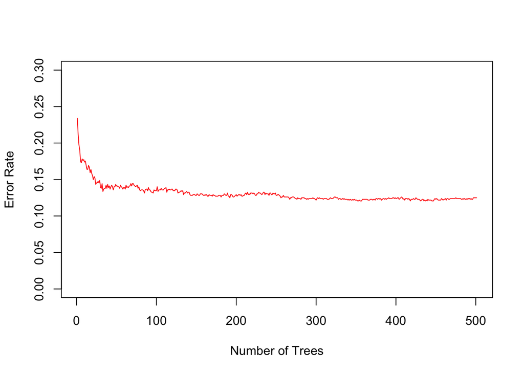

```r
# each row in rf$err.rate represent the number of trees (from 1 to ntree) included in the model.
# The OOB column shows the overall error rate (misclassification rate) across all classes.
# the Reject and Accept columns show the per-class error rate
plot(1:best_ntree_rf, rf$err.rate[, 1],
     col = "red",
     type = "l",
     xlab = "Number of Trees",
     ylab = "Error Rate", ylim = c(0, 0.3))
```

Overall OOB error rate (the avarage)

```r
# Extract OOB error rates
rf_oob_error <- as.data.frame(rf$err.rate) # oob for each tree
rf_average_oob <- mean(rf_oob_error$OOB) # same value as the OOB estimate of error rate in rfds
rf_average_oob
```

```
## [1] 0.130373
```

OOB confusion matrix

```r
# Extract OOB votes
rf_oob_votes <- rf$votes

# OOB predictions (class with the highest vote probability)
rf_oob_predictions <- colnames(rf_oob_votes)[max.col(rf_oob_votes)]

# Confusion matrix for OOB predictions
rf_conf_matrix_oob <- table(Actual = train_data$Evaluation, Predicted = rf_oob_predictions)

# Print the confusion matrix
print(rf_conf_matrix_oob)
```

```
##         Predicted
## Actual   Accept Reject
##   Reject     37    675
##   Accept    136     80
```

OOB accuracy

```r
rf_oob_accuracy <- 1-(sum(diag(rf_conf_matrix_oob)) / sum(rf_conf_matrix_oob))
rf_oob_accuracy
```

```
## [1] 0.8739224
```

OOB sensitivity and specificity

```r
# Sensitivity
rf_oob_sensitivity <-
  (rf_conf_matrix_oob[2,1]/(rf_conf_matrix_oob[2,1]+rf_conf_matrix_oob[2,2]))*100
# Specificity
rf_oob_specificity<-
  (rf_conf_matrix_oob[1,2]/(rf_conf_matrix_oob[1,2]+rf_conf_matrix_oob[1,1]))*100

rf_oob_sensitivity
```

```
## [1] 62.96296
```

```r
rf_oob_specificity
```

```
## [1] 94.80337
```

ROC AUC

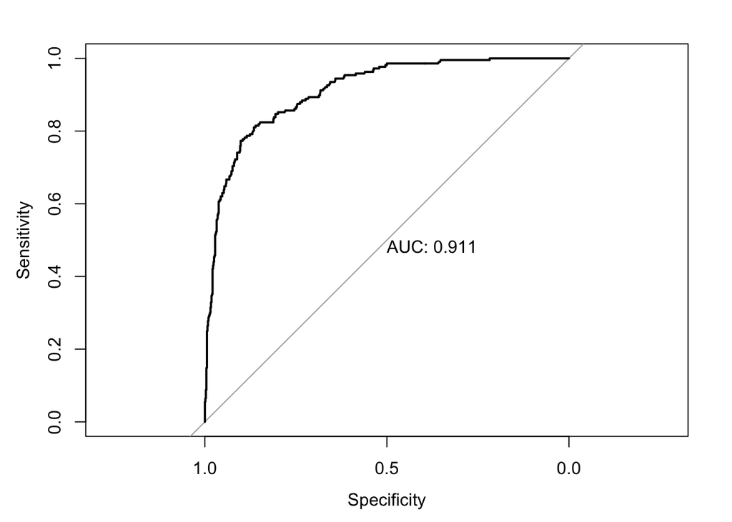

```r
rf_oob_roc <- roc(train_data$Evaluation, rf_oob_votes[, "Accept"], plot = TRUE, print.auc = TRUE)
```

```r
rf_oob_auc <- auc(rf_oob_roc)

rf_oob_roc
```

```
##
## Call:
## roc.default(response = train_data$Evaluation, predictor = rf_oob_votes[,     "Accept"], plot = TRUE, print.auc = TRUE)
##
## Data: rf_oob_votes[, "Accept"] in 712 controls (train_data$Evaluation Reject) < 216 cases (train_data$Evaluation Accept).
## Area under the curve: 0.9108
```

```r
print(rf_oob_auc)
```

```
## Area under the curve: 0.9108
```

## Test/Predict

```r
rf_pred = predict(rf, test_data)
actual_values <- test_data$Evaluation
rf_conf_matrix <- table(actual_values, rf_pred)
rf_conf_matrix
```

```
##              rf_pred
## actual_values Reject Accept
##        Reject    220      8
##        Accept     22     59
```

```r
rf_pred_accuracy <- sum(diag(rf_conf_matrix)) / sum(rf_conf_matrix)
rf_pred_accuracy
```

```
## [1] 0.9029126
```

### Sensitivity Specificity AUC

```r
# Sensitivity
rf_sensitivity <-
  (rf_conf_matrix[2,2]/(rf_conf_matrix[2,2]+rf_conf_matrix[2,1]))*100
# Specificity
rf_specificity<-
  (rf_conf_matrix[1,1]/(rf_conf_matrix[1,1]+rf_conf_matrix[1,2]))*100
```

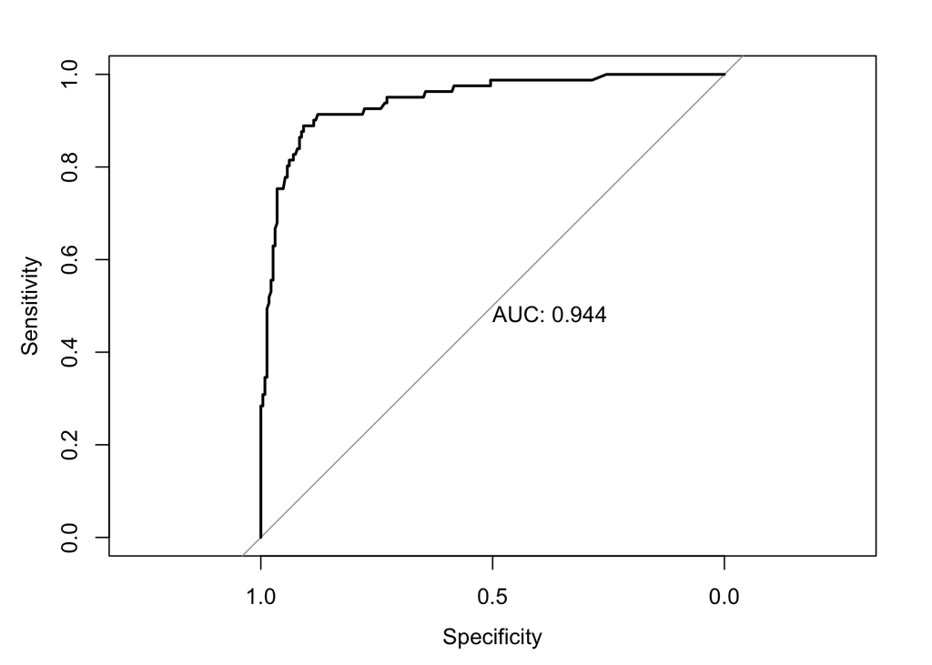

```r
# predict as probabilities instead of "Reject" and "Accept"
rf_pred_prob <- predict(rf, test_data, type="prob") %>%
  data.frame()

rf_roc <- roc(test_data$Evaluation, rf_pred_prob$Accept, plot = TRUE, print.auc = TRUE)
```

```r
rf_auc <- auc(rf_roc)
```

### Variable of importance

Variable importance measures:

- `MeanDecreaseAccuracy` (MDA) measures how much the accuracy of the Random Forest model decreases when a particular predictor variable is randomly permuted while keeping other variables constant. The larger the decrease in accuracy, the more important the variable is considered. Higher MDA values suggest that a variable is more important in making accurate predictions. Conversely, lower MDA values suggest that a variable has less influence on the model’s accuracy.
- `MeanDecreaseGini` measures how much each predictor variable contributes to the overall reduction in Gini impurity when splitting the data at each node of the tree. Gini impurity is a measure of how often a randomly chosen element would be incorrectly classified.

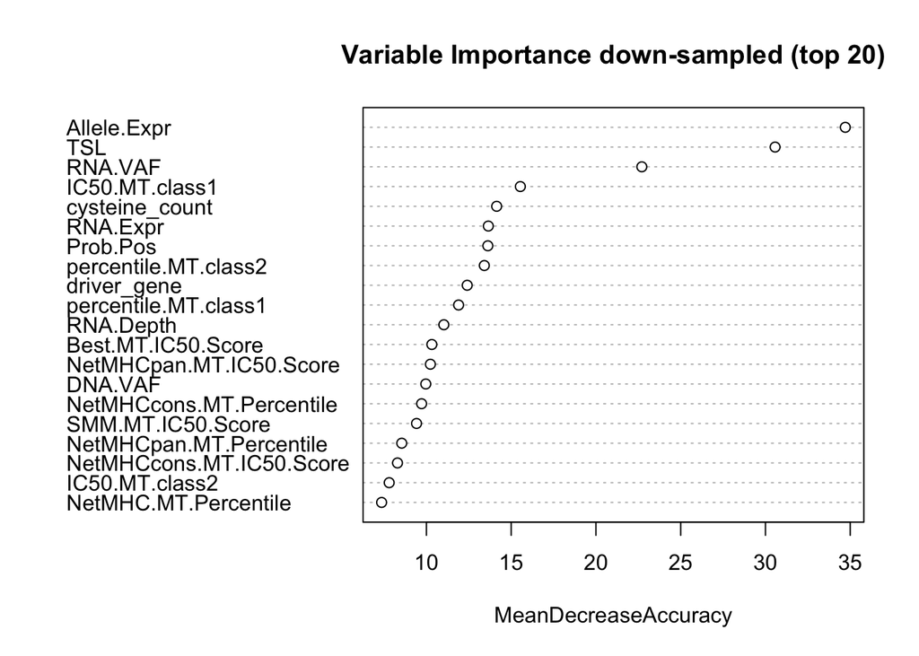

```r
# Variable importance plot (with MeanDecreaseAccuracy score)
varImpPlot(rf, sort = T, main = "Variable Importance down-sampled (top 20)", n.var = 20, type = 1) # for this to work, need to use importance = TRUE in randomForest
```

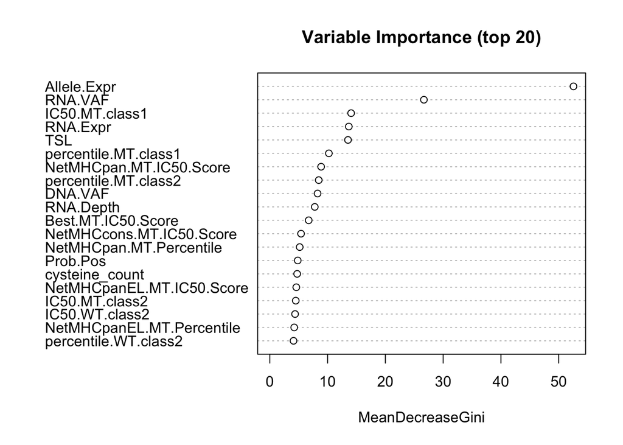

```r
# Variable importance plot (with MeanDecreaseGini score)
varImpPlot(rf, sort = T, main = "Variable Importance (top 20)", n.var = 20, type = 2)
```

```r
# print the list of all predictors ordered by importance
rf_importance <- rf$importance

# Sort the features by their importance
sorted_rf_importance <- rf_importance[order(-rf_importance[, 1]), , drop = FALSE]

# Print the sorted feature importance
#print("Feature Importance:")
#print(sorted_rf_importance)
```

Explored the out of bag misclassification error rate as a function of number of trees. We see that the error stabilizes after roughly 200 trees.

# RF with down-sampling

## Tune

Perform down-sampling: For each tree, down-sample “Reject” numbers to match the “Accept” numbers

```r
tmp = as.vector(table(train_data$Evaluation))
num_classes = length(tmp)
min_size = tmp[order(tmp, decreasing=FALSE)[1]]
sampsizes = rep(min_size, num_classes)
```

Use downsampling to tune random forest The `tuneRF()` function allows us to find the `mtry` (*m*) number that gives the least OOB error to use in the randomForrest training.

Tune ntree

make sure model is fully deterministic, so use 5001 (if it is an even number then plus 1)

## OOB

For the training data, each tree is trained on a subset of samples and a subset of features, and make predictions on the held-out set (out of bag). Each sample in the held-out set passes through the tree and gets a “vote” on whether it is Reject or Accept. This process repeats for the number of trees in the forest. The fraction of votes for Reject/Accept is an estimate of the probability of Reject/Accept and all samples will be predicted as either Reject or Accept (using probability of 0.5 as the threshold). By comparing these predictions based on the OOB data to their known class, estimates of the accuracy of the overall forest can be obtained.

```r
rfds = readRDS(file = file.path(outdir, "rf_downsample.RDS"))
```

Overall OOB error rate (the avarage)

```r
# Extract OOB error rates
rfds_oob_error <- as.data.frame(rfds$err.rate) # oob for each tree
rfds_average_oob <- mean(rfds_oob_error$OOB) # same value as the OOB estimate of error rate in rfds
rfds_average_oob
```

```
## [1] 0.1407263
```

OOB confusion matrix

```r
# Extract OOB votes
rfds_oob_votes <- rfds$votes

# OOB predictions (class with the highest vote probability)
rfds_oob_predictions <- colnames(rfds_oob_votes)[max.col(rfds_oob_votes)]

# Confusion matrix for OOB predictions
rfds_conf_matrix_oob <- table(Actual = train_data$Evaluation, Predicted = rfds_oob_predictions)

# Print the confusion matrix
print(rfds_conf_matrix_oob)
```

```
##         Predicted
## Actual   Accept Reject
##   Reject     88    624
##   Accept    175     41
```

OOB accuracy

```r
rfds_oob_accuracy <- 1-(sum(diag(rfds_conf_matrix_oob)) / sum(rfds_conf_matrix_oob))
rfds_oob_accuracy
```

```
## [1] 0.8609914
```

OOB sensitivity and specificity

```r
# Sensitivity
rfds_oob_sensitivity <-
  (rfds_conf_matrix_oob[2,1]/(rfds_conf_matrix_oob[2,1]+rfds_conf_matrix_oob[2,2]))*100
# Specificity
rfds_oob_specificity <-
  (rfds_conf_matrix_oob[1,2]/(rfds_conf_matrix_oob[1,2]+rfds_conf_matrix_oob[1,1]))*100

rfds_oob_sensitivity
```

```
## [1] 81.01852
```

```r
rfds_oob_specificity
```

```
## [1] 87.64045
```

ROC AUC

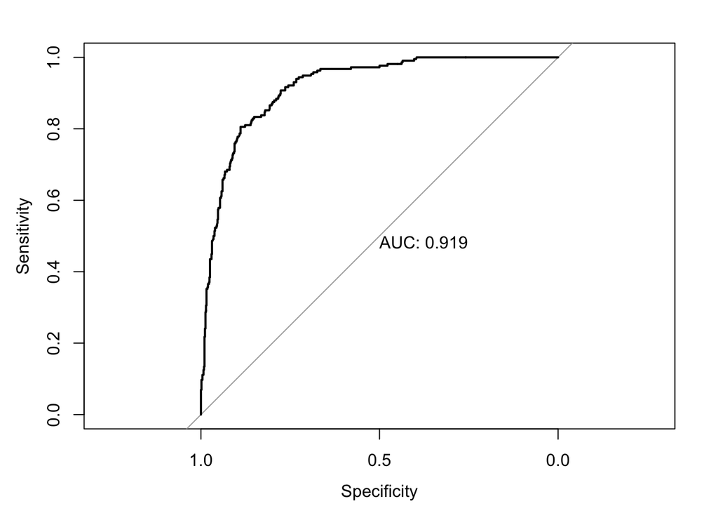

```r
rfds_oob_roc <- roc(train_data$Evaluation, rfds_oob_votes[, "Accept"], plot = TRUE, print.auc = TRUE)
```

```r
rfds_oob_auc <- auc(rfds_oob_roc)

rfds_oob_roc
```

```
##
## Call:
## roc.default(response = train_data$Evaluation, predictor = rfds_oob_votes[,     "Accept"], plot = TRUE, print.auc = TRUE)
##
## Data: rfds_oob_votes[, "Accept"] in 712 controls (train_data$Evaluation Reject) < 216 cases (train_data$Evaluation Accept).
## Area under the curve: 0.9189
```

```r
print(rfds_oob_auc)
```

```
## Area under the curve: 0.9189
```

## Prediction on test set

Make predictions on the test set

```r
rfds_pred = predict(rfds, test_data)

# save the predictions from the down-sampled random forest model
saveRDS(rfds_pred, file = file.path(outdir, "rf_pred_downsample.RDS"))

# Confusion matrix
actual_values <- test_data$Evaluation
rfds_conf_matrix <- table(actual_values, rfds_pred)
rfds_conf_matrix
```

```
##              rfds_pred
## actual_values Reject Accept
##        Reject    198     30
##        Accept      9     72
```

### Accuracy

```r
rfds_pred_accuracy <- sum(diag(rfds_conf_matrix)) / sum(rfds_conf_matrix)
rfds_pred_accuracy
```

```
## [1] 0.8737864
```

### Sensitivity Specificity AUC

```r
# Sensitivity
rfds_sensitivity <-
  (rfds_conf_matrix[2,2]/(rfds_conf_matrix[2,2]+rfds_conf_matrix[2,1]))*100
# Specificity
rfds_specificity<-
  (rfds_conf_matrix[1,1]/(rfds_conf_matrix[1,1]+rfds_conf_matrix[1,2]))*100

rfds_sensitivity
```

```
## [1] 88.88889
```

```r
rfds_specificity
```

```
## [1] 86.84211
```

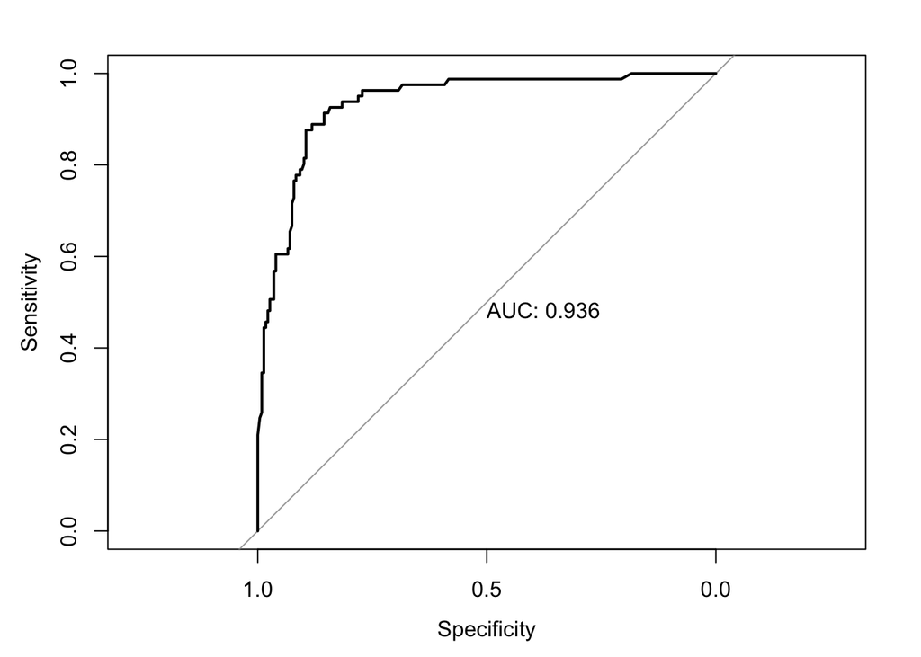

```r
# predict as probabilities instead of "Reject" and "Accept"
rfds_pred_prob <- predict(rfds, test_data, type="prob") %>%
  data.frame()
#rfds_pred <- data.frame(tree_pred)

rfds_roc <- roc(test_data$Evaluation, rfds_pred_prob$Accept, plot = TRUE, print.auc = TRUE)
```

```r
rfds_auc <- auc(rfds_roc)
```

ROC

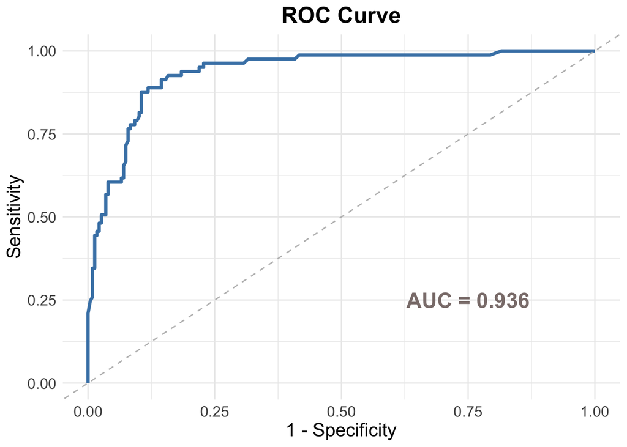

```r
# Generate the ROC curve object
rfds_roc <- roc(test_data$Evaluation, rfds_pred_prob$Accept)
# Extract ROC curve data for plotting
roc_data <- data.frame(
  specificity = rev(1 - rfds_roc$specificities),
  sensitivity = rev(rfds_roc$sensitivities)
)

# Calculate the AUC
rfds_auc <- round(auc(rfds_roc), 3)

# Plot the ROC curve using ggplot2
downsample_roc <- ggplot(roc_data, aes(x = specificity, y = sensitivity)) +
  geom_line(color = "steelblue", size = 1.25) +
  geom_abline(slope = 1, intercept = 0, linetype = "dashed", color = "gray") +
  labs(
    title = "ROC Curve",
    x = "1 - Specificity",
    y = "Sensitivity"
  ) +
  theme_minimal() +
  theme(
    plot.title = element_text(hjust = 0.5, size = 18, face = "bold"),
    axis.title = element_text(size = 15),
    axis.text = element_text(size = 12)
  ) +
  annotate(
    "text",
    x = 0.75,
    y = 0.25,
    label = paste("AUC =", rfds_auc),
    size = 6,
    color = "mistyrose4",
    fontface = "bold"
  )
downsample_roc
```

```r
ggsave(filename = file.path(outdir, "downsample_roc.png"), plot = downsample_roc, width = 8, height = 5, dpi = 300)
```

### Prediction probabilities plot

**NOT USED ANYMORE**

Separate the test set peptides based on their true accept reject labels, then plot their predicted probabilities

```r
rfds_pred_prob <- predict(rfds, test_data, type = "prob") %>%
  data.frame()

test_data_downsample_prob <- bind_cols(test_data, rfds_pred_prob)
```

```r
true_accept_prob <- test_data_downsample_prob %>% filter(Evaluation == "Accept") %>% select(Accept)
quantile(true_accept_prob$Accept, 0.1)
```

```
##      10%
## 0.478803
```

[figure not shown]

For true Accept peptides, plot the probability distribution of them classified as Accept and Reject.

### Variable of importance

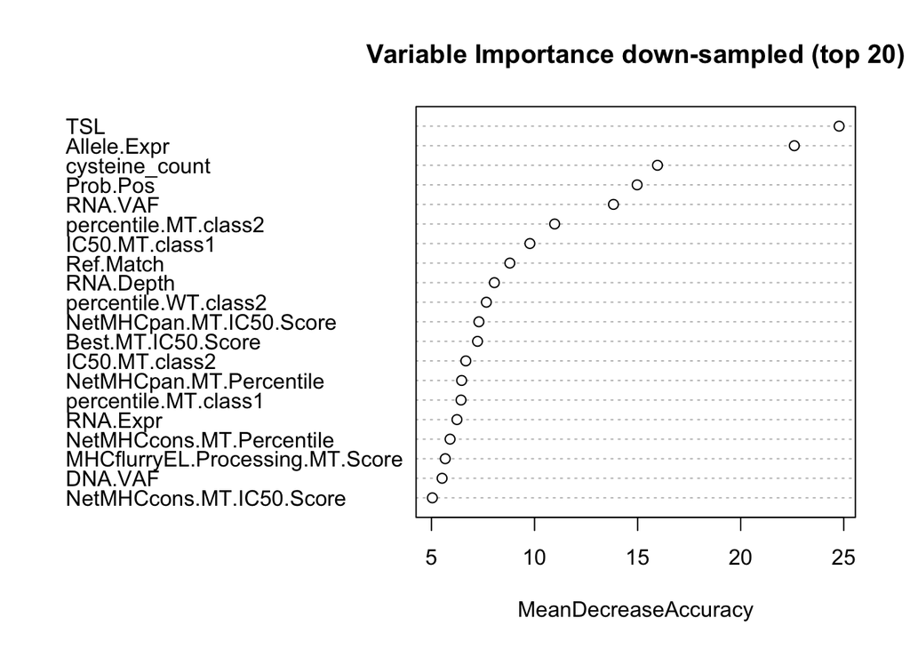

```r
# Variable importance plot (with MeanDecreaseAccuracy score)
varImpPlot(rfds, sort = T, main = "Variable Importance down-sampled (top 20)", n.var = 20, type = 1)
```

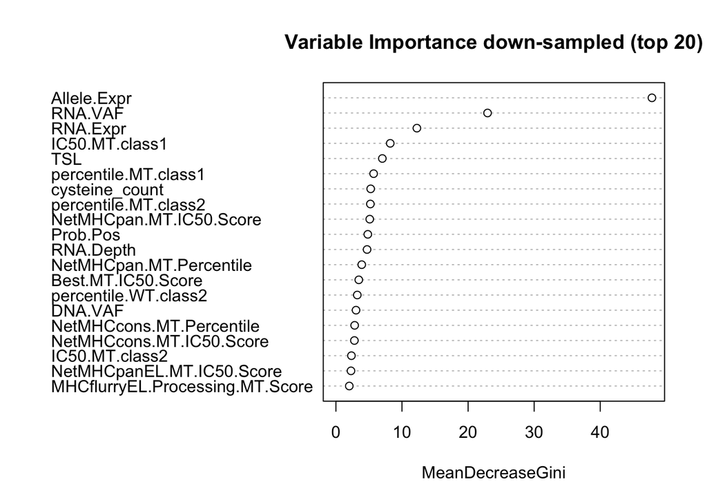

```r
# Variable importance plot (with MeanDecreaseGini score)
varImpPlot(rfds, sort = T, main = "Variable Importance down-sampled (top 20)", n.var = 20, type = 2)
```

ggplot version of variable of importance (MDA)

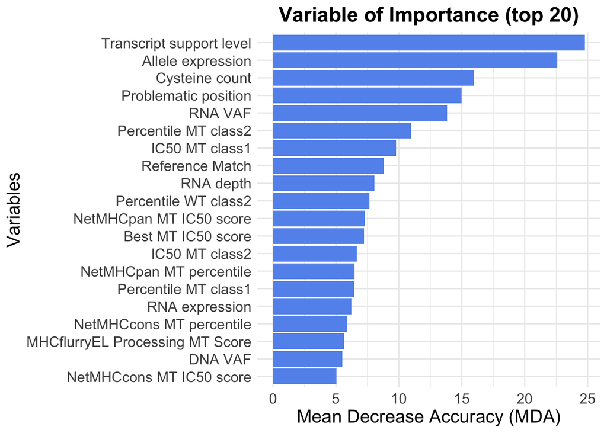

```r
# Assuming rfds is your random forest model
# Get the variable importance values
var_importance <- importance(rfds, type = 1)
var_importance <- data.frame(Variable = rownames(var_importance), Importance = var_importance[,1])

# Sort the variable importance values and select the top 20
top_var_importance <- var_importance %>%
  arrange(desc(Importance)) %>%
  head(20)

# A list of full names of the top 15 variables
var_importance_full_name <- c("Transcript support level",
                              "Allele expression",
                              "Cysteine count",
                              "Problematic position",
                              "RNA VAF",
                              "Percentile MT class2",
                              "IC50 MT class1",
                              "Reference Match",
                              "RNA depth",
                              "Percentile WT class2",
                              "NetMHCpan MT IC50 score",
                              "Best MT IC50 score",
                              "IC50 MT class2",
                              "NetMHCpan MT percentile",
                              "Percentile MT class1",
                              "RNA expression",
                              "NetMHCcons MT percentile",
                              "MHCflurryEL Processing MT Score",
                              "DNA VAF",
                              "NetMHCcons MT IC50 score"
                              )

# Modify the variable names as needed
# Example: Add "Var_" prefix to each variable name
top_var_importance$Variable <- var_importance_full_name

write.csv(top_var_importance, file = here(outdir, "var_importance_name_anno.csv"), row.names = TRUE)

# Plot the top 20 variable importance values using ggplot2
downsample_var_imp_bar <- ggplot(top_var_importance, aes(x = reorder(Variable, Importance), y = Importance)) +
  geom_bar(stat = "identity", fill = "cornflowerblue") +
  coord_flip() +
  labs(
    title = "Variable of Importance (top 20)",
    x = "Variables",
    y = "Mean Decrease Accuracy (MDA)"
  ) +
  theme_minimal() +
  theme(
    plot.title = element_text(hjust = 0.5, size = 17, face = "bold"),
    axis.title = element_text(size = 15),
    axis.text = element_text(size = 12)
  )
downsample_var_imp_bar
```

```r
# Save the plot as a PNG file
ggsave(filename = file.path(outdir, "var_importance_20.png"), plot = downsample_var_imp_bar, width = 8, height = 5, dpi = 300)
```

Variable importance whole list

```r
importance_scores <- importance(rfds)
```

## Predict on “Review” class

For training and testing above, the dataset did not include peptides under “Review”. We can apply the model on these peptides to see that the predicted probabilities are, and see if they fall in a middle area between 1 (Accept) and 0 (Reject)

```r
df_review <- df_ml %>%
  filter(Evaluation == "Review") %>%
  mutate(across(where(is.numeric), scale))
```

```r
rfds_pred_review = predict(rfds, df_review)
actual_values_review <- df_review$Evaluation
rfds_review_conf_matrix <- table(actual_values_review, rfds_pred_review)
rfds_review_conf_matrix
```

```
##                     rfds_pred_review
## actual_values_review Reject Accept
##              Accept       0      0
##              Pending      0      0
##              Reject       0      0
##              Review      86      1
```

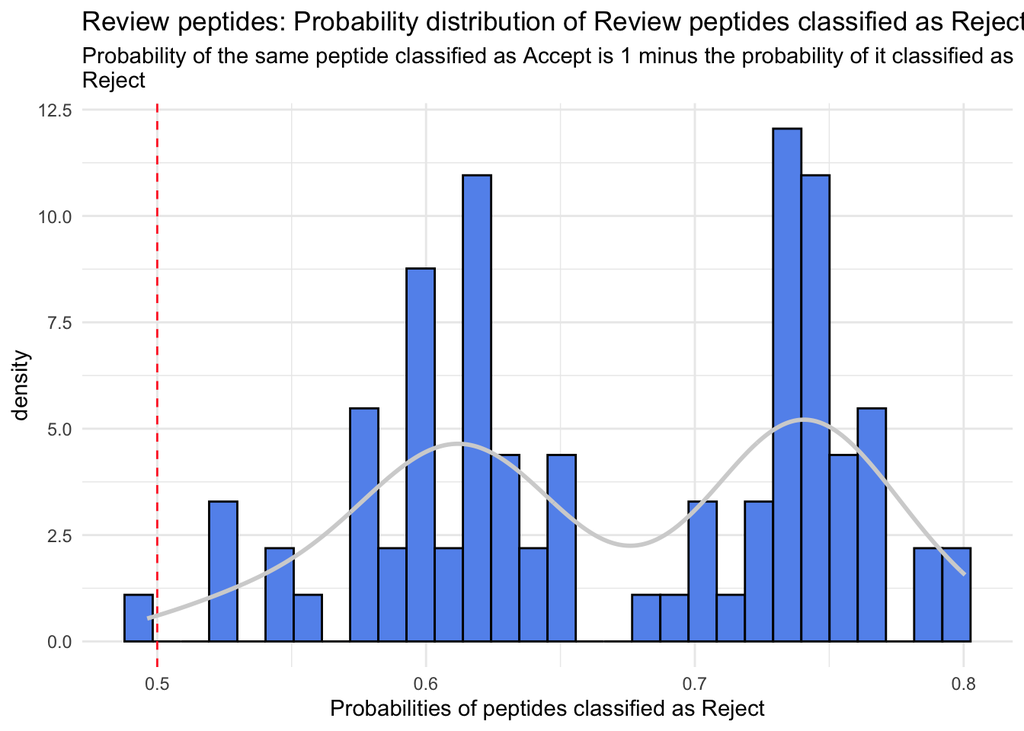

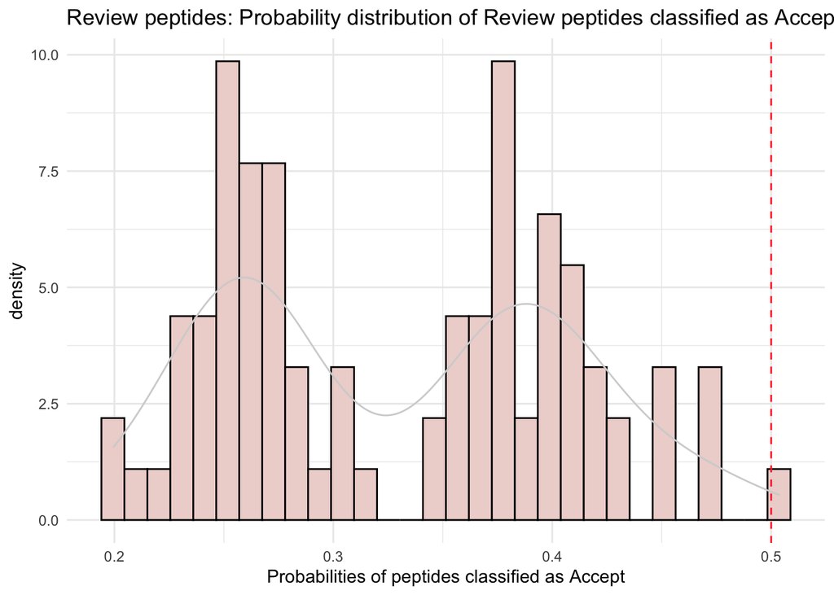

# One VS Rest Random Forest

One-vs-Rest (OvR) or One-vs-All (OvA):

- In this approach, you train a separate Random Forest model for each class. Each model is trained to distinguish one class from the rest.
- During prediction, you run all models on a new data point, and the class assigned by the model with the highest probability becomes the final prediction.

```r
df_all <- df_ml %>%
  mutate(Evaluation = as.character(Evaluation)) %>%
  mutate(Evaluation = ifelse(Evaluation == "Pending", "Reject", Evaluation)) %>%
  mutate(Evaluation = factor(Evaluation, levels = unique(Evaluation))) %>%
  mutate(across(where(is.numeric), scale)) # Scale the numeric predictors so they each have 0 mean 1 sd

summary(df_all$Evaluation)
```

```
## Accept Reject Review
##    297    940     87
```

Training and testing data is split as 75% and 25%

```r
# Set seed for reproducibility
set.seed(918)

# Number of total rows in the dataset
total_rows <- nrow(df_all)

# Number of rows for training (75%) and testing (25%)
train_rows <- round(0.75 * total_rows)  # 75% for training
test_rows <- total_rows - train_rows  # 25% for testing

# Randomly select the rows for training
train_indices <- sample(1:total_rows, train_rows)

# Create the training and testing datasets
train_data_all <- df_all[train_indices, ] %>%
  select(-c(ID, patient_id)) %>%
  na.omit()
test_data_all <- df_all[-train_indices, ] %>%
  select(-c(ID, patient_id)) %>%
  na.omit()
```

Training and testing data summary

```r
train_data_all %>% select(Evaluation) %>% summary()
```

```
##   Evaluation
##  Accept:218
##  Reject:711
##  Review: 64
```

```r
test_data_all %>% select(Evaluation) %>% summary()
```

```
##   Evaluation
##  Accept: 79
##  Reject:229
##  Review: 23
```

## Training

```r
set.seed(918)
## Tuned random forest
tune = tuneRF(train_data[, 2 : ncol(train_data)], train_data[, 1], ntreeTry = 5000)
#tune_df <- data.frame(tune)
best_mtry <- tune %>%
  data.frame() %>%
  filter(OOBError == min(OOBError)) %>%
  pull(mtry)
```

```r
# Define the class labels (replace with your actual class labels)
class_labels <- c("Accept", "Reject", "Review")

# Initialize an empty list to store the models
rf_models <- list()

for (i in 1:length(class_labels)) {
  # Create binary labels (1 for the current class, 0 for the rest)
  train_data <- train_data_all %>%
    mutate(Evaluation = ifelse(Evaluation == class_labels[i], 1, 0)) %>%
    mutate(Evaluation = factor(Evaluation, levels = 0:1))

  # Tune random forest for best mtry with lowest oob error
  set.seed(918)
  #tune = tuneRF(train_data[, 2 : ncol(train_data)], train_data[, 1], ntreeTry = 5000)
  #best_mtry <- tune %>%
      #data.frame() %>%
    #filter(OOBError == min(OOBError)) %>%
    #pull(mtry)

  # get the sample size of the smaller class
  tmp = as.vector(table(train_data$Evaluation))
  num_classes = length(tmp)
  min_size = tmp[order(tmp, decreasing=FALSE)[1]]
  sampsizes = rep(min_size, num_classes)

  # Tune mtry
  tune = tuneRF(train_data[, 2 : ncol(train_data)], train_data[, 1],
              ntreeTry = 10000,
              sampsize = sampsizes)
  # extract best mtry value that gives the lowest OOB error
  best_mtry <- tune %>%
      data.frame() %>%
    filter(OOBError == min(OOBError)) %>%
    pull(mtry)

  # Tune ntree
  # Create a Random Forest model with a range of ntree values
  ntree_values <- seq(1, 5000, by = 50)  # Adjust the range as needed
  oob_errors <- numeric(length(ntree_values))

  ## For parallel processing
  # Detect the number of cores available
  num_cores <- detectCores() - 3  # Use one less than the total number of cores
  # Create a cluster
  cl <- makeCluster(num_cores)
  # Register the parallel backend
  registerDoParallel(cl)
  # Run the process in parallel
  oob_errors <- foreach(i = 1:length(ntree_values), .combine = c, .packages = "randomForest") %dopar% {
    rf_model <- randomForest(Evaluation ~ .,
                            data = train_data,
                            ntree = ntree_values[i],
                            mtry = best_mtry,
                            sampsize = sampsizes)
    rf_model$err.rate[nrow(rf_model$err.rate), "OOB"]
  }

  # Stop the cluster
  stopCluster(cl)

  # Create a dataframe to store the results
  tune_results <- data.frame(ntree = ntree_values, OOB_Error = oob_errors)
  # Extract the best ntree value with the lowest OOB error
  best_ntree <- tune_results$ntree[which.min(tune_results$OOB_Error)]

  # Train a Random Forest model with downsampling
  rf_model <- randomForest(Evaluation ~ ., data = train_data,
                             importance = TRUE, ntree = best_ntree, mtry = best_mtry,
                             proximity = TRUE, sampsize = sampsizes, na.action = na.omit)

  # Store the model in the list
  rf_models[[i]] <- rf_model
}

# save random forests models
saveRDS(rf_models, file.path(outdir, "one_vs_rest_rfds.rds"))
```

```r
rf_models <- readRDS(file = file.path(outdir, "one_vs_rest_rfds.rds"))
```

## OOB error for each model

```r
class_labels <- c("Accept", "Reject", "Review")

# Initialize lists to store results
oob_errors <- numeric(length(rf_models))
sensitivity_specificity <- list()

# Loop through each model in rf_models
for (i in seq_along(rf_models)) {
  model <- rf_models[[i]]

  # Extract OOB error
  oob_errors[i] <- model$err.rate[nrow(model$err.rate), "OOB"]

  # Extract OOB predictions and actual labels
  oob_predictions <- model$predicted  # OOB predictions
  actual_labels <- model$y            # Actual labels in training data

  # Construct confusion matrix
  conf_matrix <- table(Predicted = oob_predictions, Actual = actual_labels)

  # Calculate sensitivity and specificity
  class_metrics <- data.frame(Model = NA, Sensitivity = NA, Specificity = NA)

  # levels(actual_labels) are "0" and "1"
  # the conf_matrix is structured as:
    # Row: predicted "0", "1"
    # Columns: predicted "0", "1"

  TP <- conf_matrix["1", "1"]  # True positives
  FN <- conf_matrix["0", "1"]  # False negatives
  FP <- conf_matrix["1", "0"]  # False positives
  TN <- conf_matrix["0", "0"]  # True negatives

  # Sensitivity and Specificity
  sensitivity <- TP / (TP + FN)
  specificity <- TN / (TN + FP)

  # Store results
  class_metrics$Model <- seq_along(rf_models)[i]
  class_metrics$Sensitivity <- sensitivity
  class_metrics$Specificity<- specificity

  # Store metrics for this model
  sensitivity_specificity[[i]] <- class_metrics
}

ovr_oob_results <- bind_rows(sensitivity_specificity) %>%
  mutate(Model = recode(Model,
                         "1" = "Accept VS rest",
                         "2" = "Reject VS rest",
                         "3" = "Review VS rest"))

ovr_oob_results
```

```
##            Model Sensitivity Specificity
## 1 Accept VS rest   0.8211009   0.8580645
## 2 Reject VS rest   0.8691983   0.7411348
## 3 Review VS rest   0.2500000   0.8794403
```

## Prediction

For each test data point in test_data_all, make predictions using all models. The class with the highest predicted probability becomes the final prediction.

```r
# Initialize an empty matrix to store predictions
num_test_samples <- nrow(test_data_all)
predictions <- matrix(NA, nrow = num_test_samples, ncol = length(class_labels))

for (i in 1:length(class_labels)) {
  # Predict the probability of the current class
  test_data <- test_data_all

  predicted_prob <- predict(rf_models[[i]], newdata = test_data, type = "prob")[, "1"]
  # choose the predicted probabilities of "1"s in each model

  # Store the predicted probability in the matrix
  predictions[, i] <- predicted_prob
}

head(predictions)
```

```
##            [,1]       [,2]      [,3]
## [1,] 0.47786347 0.52956189 0.3113443
## [2,] 0.01856612 0.96937473 0.3268366
## [3,] 0.48471865 0.47256487 0.4582709
## [4,] 0.06598115 0.73755849 0.4407796
## [5,] 0.91688089 0.09017439 0.2943528
## [6,] 0.46101114 0.60442365 0.4247876
```

```r
# Determine the class with the highest predicted probability for each test sample
predicted_classes <- class_labels[apply(predictions, 1, which.max)]
```

```r
true_classes <- test_data_all$Evaluation
rf_ovr_confusion_matrix <- table(true_classes, predicted_classes)
rf_ovr_accuracy <- sum(diag(rf_ovr_confusion_matrix)) / sum(rf_ovr_confusion_matrix)
rf_ovr_recall <- diag(rf_ovr_confusion_matrix) / rowSums(rf_ovr_confusion_matrix)
rf_ovr_precision <- diag(rf_ovr_confusion_matrix) / colSums(rf_ovr_confusion_matrix) # also Positive Predictive Value
#f1_score <- 2 * (precision * recall) / (precision + recall)

rf_ovr_confusion_matrix
```

```
##             predicted_classes
## true_classes Accept Reject Review
##       Accept     59     18      2
##       Reject     37    185      7
##       Review      7     11      5
```

```r
rf_ovr_accuracy
```

```
## [1] 0.7522659
```

```r
rf_ovr_recall
```

```
##    Accept    Reject    Review
## 0.7468354 0.8078603 0.2173913
```

```r
rf_ovr_precision
```

```
##    Accept    Reject    Review
## 0.5728155 0.8644860 0.3571429
```

# Summary

## Accept VS Reject models

Model Performance Metrics (Accept VS Reject models)

| Model | Dataset | Metrics Accuracy | Metrics Sensitivity | Metrics Specificity | Metrics AUC |
| --- | --- | --- | --- | --- | --- |
| Random Forest | Out-of-Bag | 0.874 | 62.963 | 94.803 | 0.911 |
|  | Held-out Test | 0.903 | 72.840 | 96.491 | 0.944 |
| Random Forest Downsampling | Out-of-Bag | 0.861 | 81.019 | 87.640 | 0.919 |
|  | Held-out Test | 0.874 | 88.889 | 86.842 | 0.936 |

For the downsampled model, we plotted the probability distribution of Accept peptides being predicted as Accept (1)

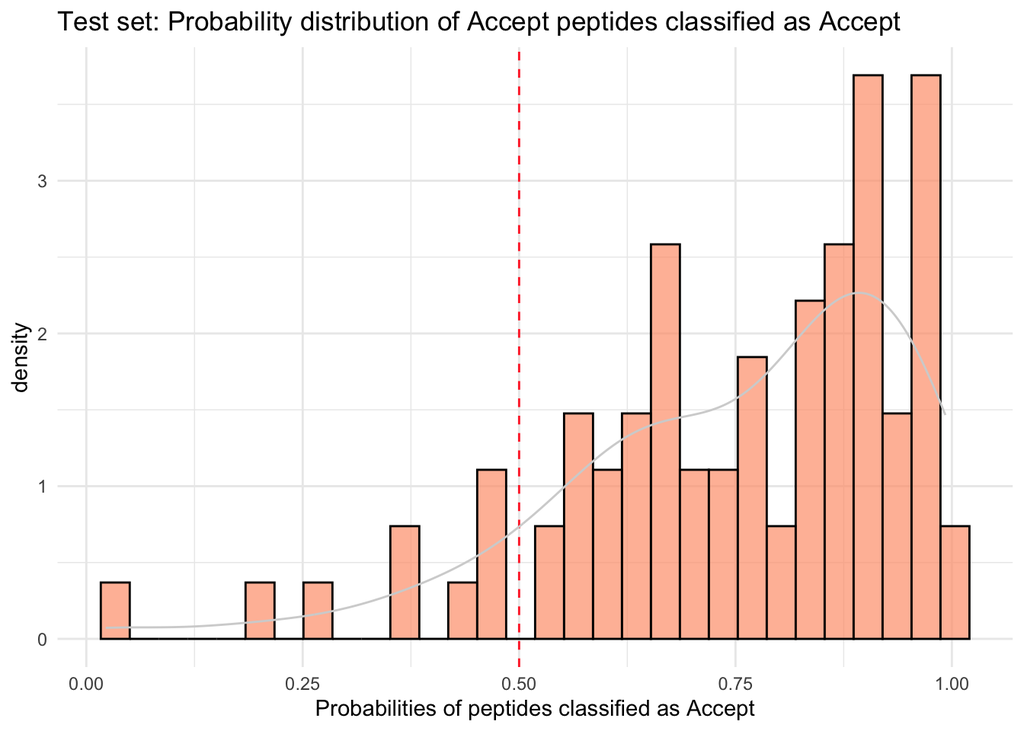

For Reject peptides, plotted the probability distribution of these peptides being predicted as Accept (2)

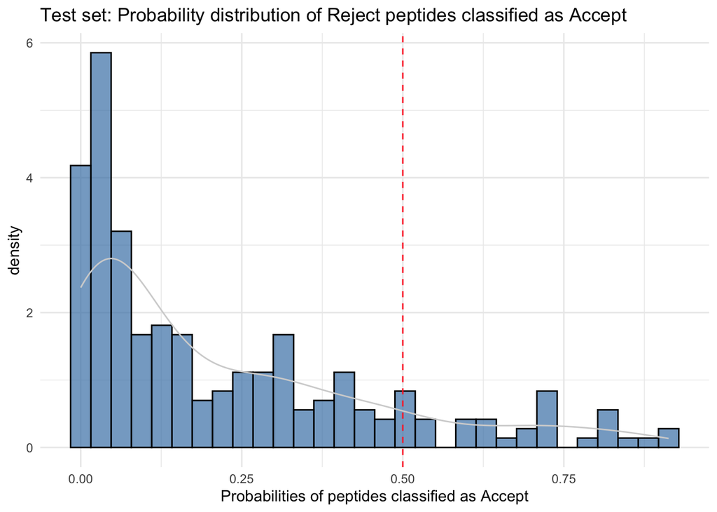

To see how the model performs on the Review peptides, which were not included in the training or testing set, we plotted the probability distribution of these peptides being predicted as Accept (3)

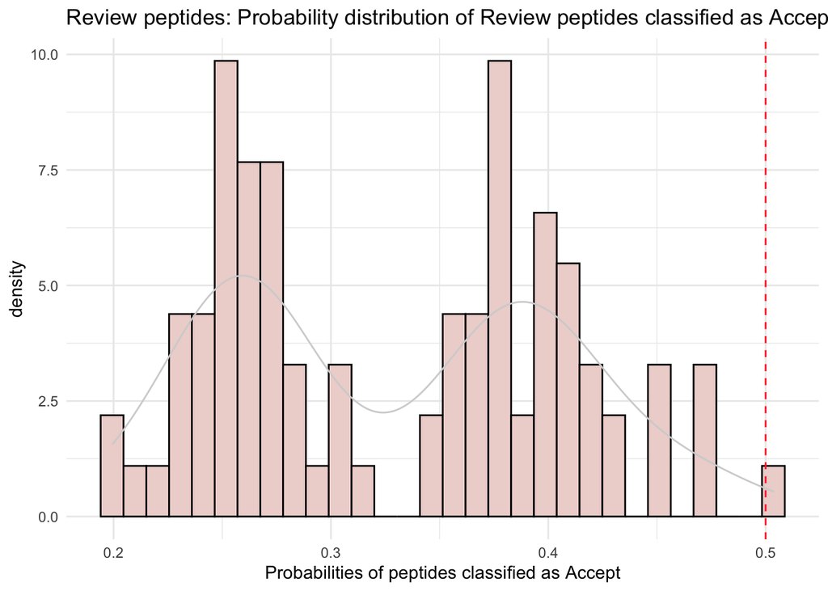

## One-VS-Rest model

OOB sensitivity and specificity

| Model | Sensitivity | Specificity |
| --- | --- | --- |
| Accept VS rest | 0.8211009 | 0.8580645 |
| Reject VS rest | 0.8691983 | 0.7411348 |
| Review VS rest | 0.2500000 | 0.8794403 |

Confusion Matrix

```
##             predicted_classes
## true_classes Accept Reject Review
##       Accept     59     18      2
##       Reject     37    185      7
##       Review      7     11      5
```

Accuracy

```
## [1] 0.7522659
```

# Next step

- Get a set of prediction numbers for training data – may look better
- Set thresholds (test different thresholds) such that we allow e.g. 10% of Accept peptides to be classified as Reject, 10% of Reject peptides that are classified as Accept, then things between the thresholds are “Review”
- Set up the pipeline to test it on one patient’s sample
  - download itb_review, all_epitopes, class2 files of that patient
  - save them into folders
  - run the pipeline on those files
  - paste the predicted Evaluations back to the itb_review file
  - upload itb_review_ml_predict back to PVACview to see how if the Evaluations show up
- For each new case that is reviewed by the tumor board, count how many of the peptides were changed from the ml_predict predictions
- Keep note of the time it takes for them to review the peptides